# Wordle Data Analysis Report

Brenda Luis

2025-12-03

# **Introduction**

Wordle is a daily word puzzle in which players attempt to guess a five-letter English word within six attempts. Each guess provides structured feedback based on letter accuracy and placement. Although the game appears simple, its dataset of solutions contains linguistic patterns that can be statistically analyzed.

The goal of this project is to understand the structure of the official Wordle answer list. By examining letter usage, positional behavior, bigram patterns, repeated-letter distributions, and relationships between word frequency and Scrabble score, this project answers the broader question:

**Does Wordle follow predictable linguistic patterns, and how can these patterns improve player strategy?**

This problem is meaningful because understanding these trends allows players to make more informed guesses and reveals how puzzle designers curate word lists.

# **Questions to Answer**

This analysis focuses on the following core questions:

1. Which letters appear more frequently in Wordle solutions?
2. Which letters appear more frequently in Wordle solutions by position?
3. Which letter pairs (bigrams) appear most often in Wordle solutions?
4. How does the bigram frequency change depending on where they appear in the word?
5. Do repeated letter Wordle answers follow seasonal or monthly patterns across different years?
6. Is there a relationship between a word’s frequency in English and its Scrabble point value?

# **Required Packages**

```r
# libraries
library(ggplot2)    # plot visualization
library(dplyr)      # summarizing, filtering, etc
library(tidyr)      # reshaping data (pivot, etc)
library(kableExtra) # nice looking tables
library(gridExtra)  # arranging multiple plots next to each other
library(patchwork)  # another tool to combine plots
library(calendR)    # generating monthly heatmaps
library(lubridate)  # date handling
library(ggthemes)   # different plot themes
```

# **Dataset Information**

The dataset contains official Wordle answers from 2021 to 2025, scraped from:

https://wordfinder.yourdictionary.com/wordle/answers/

Each row represents one day’s solution.

wordle_data is a data frame with 1609 rows and 28 variables:

| Variable | Type | Description |
| --- | --- | --- |
| Date | date | Publication date of the puzzle |
| Wordle.Number | integer | Sequential ID of the puzzle |
| Answer | character | Correct 5-letter Wordle answer |
| Weekday | character | Day of the week |
| Month | character | Month name |
| Day | integer | Day of month |
| Year | integer | Year |
| Has.Repeated.Letters | integer | 1 if the word contains repeated letters |
| All.unique.letters | integer | 1 if all letters in the word are unique |
| Starts.with.vowel | integer | 1 if the word starts with a vowel |
| Ends.with.vowel | integer | 1 if the word ends with a vowel |
| Num.vowels | integer | Number of vowels |
| Num.consonants | integer | Number of consonants |
| Ends.with.Y | integer | 1 if the word ends with ‘Y’ |
| Has.rare.letter | integer | 1 if the word contains Q, Z, X, or J |
| Contains.common.prefix | integer | 1 if it contains RE, UN, IN, IM, DE, EX, or BE |
| Contains.common.suffix | integer | 1 if it contains ED, ER, LY, ES, ST, NT, TH, CH, SH |
| P1–P5 | character | Letters in each of the 5 positions |
| Word.Frequency | numeric | English frequency score (0–1) |
| Scrabble.score | integer | Scrabble point value |
| Frequency.category | character | Frequency category |
| Top.row.letters | integer | Count of top-row keyboard letters |
| Mid.row.letters | integer | Count of middle-row keyboard letters |
| Bottom.row.letters | integer | Count of bottom-row keyboard letters |

# **Data Loading**

```r
# load data from csv
wordle_data <- read.csv("wordle_data.csv")

# convert Date column from string to date object
wordle_data <- wordle_data %>%
  mutate(Date = as.Date(Date, format = "%Y-%m-%d"))

# convert Month and Weekday columns to factors
wordle_data <- wordle_data %>%
  mutate(
    Month = factor(Month, levels = month.name, ordered = TRUE),
    Weekday = factor(Weekday, levels = c("Sunday","Monday","Tuesday","Wednesday","Thursday","Friday","Saturday"), ordered = TRUE)
  )

# display random sample from data
wordle_data %>%
  sample_n(10) %>%
  arrange(Date) %>%
  kbl() %>%
  kable_styling() %>%
  scroll_box(width = "100%", height = "400px")
```

| Date | Wordle.Number | Answer | Weekday | Month | Day | Year | Has.repeated.letters | Starts.with.vowel | Ends.with.vowel | Num.vowels | Num.consonants | Has.rare.letter | Contains.common.suffix | All.unique.letters | P1 | P2 | P3 | P4 | P5 | Contains.common.prefix | Word.Frequency | Scrabble.score | Frequency.category | Top.row.letters | Mid.row.letters | Bottom.row.letters | Ends.with.Y |
| --- | --- | --- | --- | --- | --- | --- | --- | --- | --- | --- | --- | --- | --- | --- | --- | --- | --- | --- | --- | --- | --- | --- | --- | --- | --- | --- | --- |
| 2022-01-13 | 208 | ABBEY | Thursday | January | 13 | 2022 | 1 | 1 | 0 | 2 | 3 | 0 | 0 | 0 | A | B | B | E | Y | 0 | 7.6e-06 | 12 | uncommon | 2 | 1 | 2 | 1 |
| 2022-08-24 | 431 | NEEDY | Wednesday | August | 24 | 2022 | 1 | 0 | 0 | 2 | 3 | 0 | 0 | 0 | N | E | E | D | Y | 0 | 3.8e-06 | 9 | uncommon | 3 | 1 | 1 | 1 |
| 2024-05-10 | 1056 | MEDIA | Friday | May | 10 | 2024 | 0 | 0 | 1 | 3 | 2 | 0 | 0 | 1 | M | E | D | I | A | 0 | 2.0e-04 | 8 | common | 2 | 2 | 1 | 0 |
| 2024-05-23 | 1069 | SWISH | Thursday | May | 23 | 2024 | 1 | 0 | 0 | 1 | 4 | 0 | 1 | 0 | S | W | I | S | H | 0 | 8.0e-07 | 11 | rare | 2 | 3 | 0 | 0 |
| 2024-08-10 | 1148 | MEDIC | Saturday | August | 10 | 2024 | 0 | 0 | 0 | 2 | 3 | 0 | 0 | 1 | M | E | D | I | C | 0 | 2.6e-06 | 10 | uncommon | 2 | 1 | 2 | 0 |
| 2024-08-25 | 1163 | SKATE | Sunday | August | 25 | 2024 | 0 | 0 | 1 | 2 | 3 | 0 | 0 | 1 | S | K | A | T | E | 0 | 5.5e-06 | 9 | uncommon | 2 | 3 | 0 | 0 |
| 2024-08-30 | 1168 | KNAVE | Friday | August | 30 | 2024 | 0 | 0 | 1 | 2 | 3 | 0 | 0 | 1 | K | N | A | V | E | 0 | 3.0e-07 | 12 | rare | 1 | 2 | 2 | 0 |
| 2024-12-01 | 1261 | MAUVE | Sunday | December | 1 | 2024 | 0 | 0 | 1 | 3 | 2 | 0 | 0 | 1 | M | A | U | V | E | 0 | 5.0e-07 | 10 | rare | 2 | 1 | 2 | 0 |
| 2025-02-13 | 1335 | RUMBA | Thursday | February | 13 | 2025 | 0 | 0 | 1 | 2 | 3 | 0 | 0 | 1 | R | U | M | B | A | 0 | 4.0e-07 | 9 | rare | 2 | 1 | 2 | 0 |
| 2025-03-03 | 1353 | SPEAR | Monday | March | 3 | 2025 | 0 | 0 | 0 | 2 | 3 | 0 | 0 | 1 | S | P | E | A | R | 0 | 5.0e-06 | 7 | uncommon | 3 | 2 | 0 | 0 |

# **Data Analysis**

### **Question 1 - Which letters appear more frequently in Wordle solutions?**

This section analyzes the overall distribution of letters across all Wordle solutions. Each answer contains five letters, but their frequencies vary widely. Identifying these differences helps show which letters Wordle relies on most often and establishes a baseline for understanding more detailed patterns in later sections.

**Step 1: Extracting and Counting Letter Frequencies**

The code below retrieves the letter in each of the five positions (P1–P5), reshapes them into a long format, and counts how often each letter appears. Letters are also labeled as vowels and consonants to support interpretation of the results.

```r
# pulling letters, counts, and type
letter_frequency <- wordle_data %>%
  select(P1, P2, P3, P4, P5) %>%
  pivot_longer(cols = c(P1, P2, P3, P4, P5), names_to = "Position", values_to = "Letter") %>%
  group_by(Letter) %>%
  summarise(Counts = n()) %>%
  arrange(-Counts) %>%
  mutate(Type = ifelse(Letter %in% c("A","E","I","O","U"), "Vowel", "Consonant"))

# table displaying data
letter_frequency %>%
  kbl() %>%
  kable_styling() %>%
  scroll_box(width = "40%", height = "300px")
```

| Letter | Counts | Type |
| --- | --- | --- |
| E | 876 | Vowel |
| A | 706 | Vowel |
| R | 630 | Consonant |
| O | 546 | Vowel |
| T | 539 | Consonant |
| L | 496 | Consonant |
| I | 455 | Vowel |
| S | 437 | Consonant |
| N | 406 | Consonant |
| C | 322 | Consonant |
| U | 308 | Vowel |
| H | 289 | Consonant |
| D | 273 | Consonant |
| Y | 258 | Consonant |
| P | 245 | Consonant |
| G | 217 | Consonant |
| M | 217 | Consonant |
| B | 188 | Consonant |
| F | 160 | Consonant |
| K | 141 | Consonant |
| W | 129 | Consonant |
| V | 106 | Consonant |
| X | 31 | Consonant |
| Z | 29 | Consonant |
| Q | 22 | Consonant |
| J | 19 | Consonant |

This table shows the raw frequency counts for every letter that appears in any position of a Wordle solution. These values give an overview of how commonly each letter is used across the dataset.

**Step 2: Visualizing the letter frequencies**

A bar plot allows for direct comparison between more and less common letters, emphasizing the contrast between highly frequent and rarely used characters.

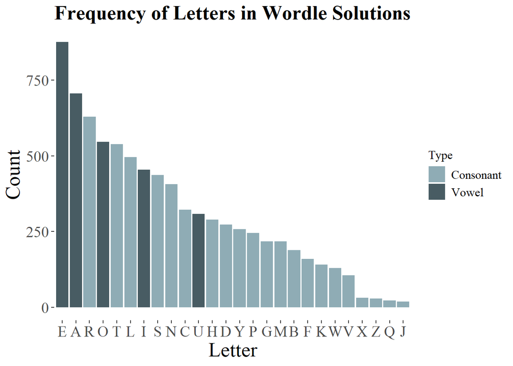

```r
# bar graph to display letter frequency
letter_frequency %>%
  ggplot(aes(x = reorder(Letter,-Counts), y = Counts, fill = Type)) +
  geom_col() +
  labs(
    title = "Frequency of Letters in Wordle Solutions",
    x = "Letter",
    y = "Count",
    fill = "Type"
  ) +
  scale_fill_manual(values = c("Vowel" = "#485c63", "Consonant" = "#8facb5")) +
  theme_tufte() +
  theme(
    plot.title = element_text(size = 20, face = "bold"),   # title size
    axis.title.x = element_text(size = 20),                # X label
    axis.title.y = element_text(size = 20),                # Y label
    axis.text.x = element_text(size = 15), # letter labels
    axis.text.y = element_text(size = 15),                  # position numbers
    legend.title = element_text(size = 12),
    legend.text = element_text(size = 12)
  )
```

The plot illustrates the clear separation between frequently and infrequently used letters. Letters such as E, A, R, O, and T appear far more often than others, while letters including X, Z, Q, and J occur rarely. This matters for Wordle strategy, since selecting guesses with high-frequency letters increases the chance of matching one or more letters in the target word, making them generally more efficient opening choices.

**Step 3: Identifying the most and least common letters**

```r
# most common letter
letter_frequency %>%
  summarise(most_common_letter = Letter[which.max(Counts)],
            frequency = max(Counts))%>%
  kbl() %>%
  kable_styling() %>%
  scroll_box(width = "50%")
```

| most_common_letter | frequency |
| --- | --- |
| E | 876 |

```r
letter_frequency %>%
  summarise(least_common_letter = Letter[which.min(Counts)],
            frequency= min(Counts))%>%
  kbl() %>%
  kable_styling() %>%
  scroll_box(width = "50%")
```

| least_common_letter | frequency |
| --- | --- |
| J | 19 |

These tables identify the single most common and least common letters in the full Wordle dataset. The first table shows that E appears 876 times, making it the most frequently used letter across all solutions. In contrast, the second table shows that J appears only 19 times, the lowest count among all letters. These values highlight the extremes of the letter-frequency distribution and reinforce the patterns observed earlier in the summary table and bar chart.

Overall, the results show that E is the most common letter, followed by A, R, O, and T. These letters appear throughout many standard English words, so it makes sense that Wordle uses them often. On the other end, letters such as X, Z, Q, and J appear very rarely. Because of this gap between common and uncommon letters, first guesses that include frequent vowels and consonants are usually more effective. This overview gives a clearer picture of Wordle’s overall letter patterns before examining more detailed structural trends within the words.

While overall letter frequency provides useful insight, it does not capture how letters behave within specific positions of a word. Wordle solutions may rely on certain letters more heavily at the beginning, middle, or end of a word, reflecting common patterns found in English word structure. Understanding these positional tendencies helps refine guessing strategies further. For this reason, the next section examines which letters appear most frequently in each of the five positions of a Wordle solution.

### **Question 2 - Which letters appear more frequently in Wordle solutions by position?**

This section examines whether certain letters are more common in specific positions within Wordle solutions. English words often follow predictable structural patterns, such as frequent starting consonants (e.g., S, C, T) and common ending letters (e.g., E, Y). Analyzing positional frequency allows us to see how closely Wordle solutions follow these linguistic tendencies. Understanding these patterns can also improve strategic guessing by highlighting which letters are more informative depending on their position in the word.

**Step 1: Identifying the most frequent letters in each position**

The following code calculates how often each letter appears in positions P1 through P5. By reshaping the dataset and summarizing counts within each position, we can identify the top-position letters and compare trends across positions.

```r
# pulling positional letter frequency data
positional_letter_frequency <- wordle_data %>%
  select(P1, P2, P3, P4, P5) %>%
  pivot_longer(cols = c(P1, P2, P3, P4, P5), names_to = "Position", values_to = "Letter") %>%
  group_by(Position, Letter) %>%
  summarise(Counts = n()) %>%
  arrange(Position, -Counts)

# table displaying data
positional_letter_frequency %>%
  group_by(Position) %>%
  slice_max(Counts, n = 3) %>%
  kbl() %>%
  kable_styling() %>%
  scroll_box(width = "50%", height = "400px")
```

| Position | Letter | Counts |
| --- | --- | --- |
| P1 | S | 237 |
| P1 | C | 133 |
| P1 | B | 121 |
| P2 | A | 206 |
| P2 | O | 202 |
| P2 | R | 189 |
| P3 | A | 241 |
| P3 | O | 188 |
| P3 | I | 175 |
| P4 | E | 207 |
| P4 | N | 130 |
| P4 | S | 120 |
| P5 | E | 327 |
| P5 | Y | 221 |
| P5 | T | 186 |

The positional frequency table shows clear patterns in how letters tend to appear in each place within a Wordle solution. In Position 1, the most frequent starting letters are S with 237 occurrences, C with 133 occurrences, and B with 121 occurrences. These findings match common English word patterns where many words begin with strong consonants. In Position 2, the most frequent letters are A with 206 occurrences, O with 202 occurrences, and R with 189 occurrences. In Position 3, vowels take the lead, with A appearing 241 times, O appearing 188 times, and I appearing 175 times.

Position 4 becomes more structured toward the end of the word. The most frequent letters in this position are E with 207 occurrences, N with 130 occurrences, and S with 120 occurrences. Finally, Position 5 shows the strongest pattern in the entire dataset. E appears 327 times, Y appears 221 times, and T appears 186 times. These values demonstrate that the first and last positions follow predictable English word structures, and the middle positions often support vowel placement or transitional consonants.

**Step 2: Visualizing positional frequency using a heatmap**

To observe the full distribution of all letters across all positions, the code below constructs a heatmap. Warmer (darker) colors represent higher frequencies, while lighter areas indicate letters that rarely occur in that position.

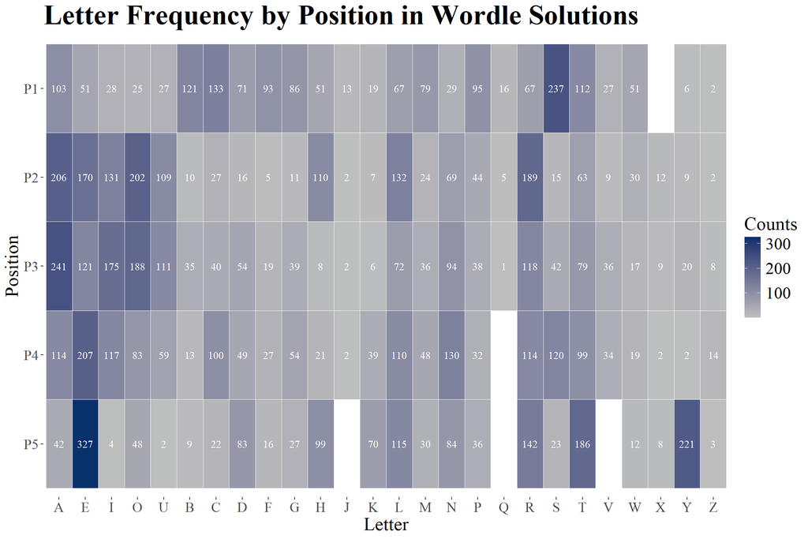

```r
# pull all letters
all_letters <- sort(unique(positional_letter_frequency$Letter))

# vowels
vowels <- c("A", "E", "I", "O", "U")

# create letter vector where vowels are in the front
# will use this to make factor
letter_vector <- c(
  vowels,
  sort(setdiff(all_letters, vowels))
)

# making letters factors
positional_letter_frequency <- positional_letter_frequency %>%
  mutate(Letter = factor(Letter, levels = letter_vector))


# reordering positions so P1 is at the top
# default order puts P5 first so I change that here
positional_letter_frequency <- positional_letter_frequency %>%
  mutate(Position = factor(Position, levels = c("P5", "P4", "P3", "P2", "P1")))


# heatmap to show letter frequency by position
positional_letter_frequency %>%
  ggplot(aes(x = Letter, y = Position, fill = Counts)) +
  geom_tile(color = "white") +
  geom_text(aes(label = Counts), color = "white", size = 4) +
  labs(
    title = "Letter Frequency by Position in Wordle Solutions",
    x = "Letter",
    y = "Position"
  ) +
  scale_fill_gradient(
    low = "grey",
    high = "#08306b"
  ) +
  theme_tufte() +
  theme(
    plot.title = element_text(size = 30, face = "bold"),   # title size
    axis.title.x = element_text(size = 20),                # X label
    axis.title.y = element_text(size = 20),                # Y label
    axis.text.x = element_text(size = 15),                 # letter labels
    axis.text.y = element_text(size = 15),                 # position numbers
    legend.title = element_text(size = 20),
    legend.text = element_text(size = 18)
  )
```

The heatmap produces a similar conclusion by displaying how these frequencies look across all letters and positions. Strong concentrations appear where large counts were observed in the table. S is heavily used at the beginning of words. A dominates Positions 2 and 3. E has a major presence in Position 4, and it is especially common in Position 5 where it reaches 327 occurrences. In contrast, letters such as J, Q, and V rarely appear in any position and are completely absent from the final position. These patterns show that Wordle solutions follow familiar English structures, which helps explain why certain guesses eliminate more possibilities than others when players know the position of a revealed letter.

Overall, the positional results show that Wordle solutions follow familiar patterns found in standard English words. Strong consonants such as S, C, and B appear very often at the beginning of words, while the ending position is dominated by E, Y, and T. The middle positions are more flexible, but they still show clear trends, especially the high presence of vowels in Positions 2 and 3. These patterns help explain why some guesses narrow down the possibilities more effectively than others. Knowing which letters commonly appear in each position allows players to interpret feedback more efficiently and update their guesses in a more informed way. With these positional patterns established, the next step is to examine how letters behave in pairs, which is addressed in the following section on bigram frequency.

### **Fun Fact!**

One observation I have made while playing Wordle is that five-letter solutions ending in the letter “S” are relatively uncommon, especially when compared to how frequently plurals occur in everyday English. A typical plural formed by adding “S” to a four-letter base word appears far less often in the official Wordle answer list.

Examples of these plural formations include:

CART → CARTS

BOOK → BOOKS

CARD → CARDS

Based on the positional data, only 23 out of more than 1,600 Wordle solutions end with S. This suggests that simple plural forms are not commonly selected as answers. This observation refers specifically to plural endings and is not related to past-tense endings such as “ED”.

The list below shows all Wordle solutions in the dataset that end with “S”:

```r
# filter words that end with S
words_end_s <- wordle_data %>%
  filter(P5 == "S") %>%
  select(Answer)

# display table
words_end_s %>%
  kbl(col.names = "Word Ending in S") %>%
  kable_styling() %>%
  scroll_box(width = "40%", height = "250px")
```

| Word Ending in S |
| --- |
| GROSS |
| LORIS |
| BLISS |
| BONUS |
| ATLAS |
| PRESS |
| BRASS |
| CHAOS |
| MINUS |
| AMASS |
| PIOUS |
| AMISS |
| ETHOS |
| LOCUS |
| CROSS |
| CLASS |
| GLASS |
| FOCUS |
| TRUSS |
| REBUS |
| ABYSS |
| CRASS |
| FLOSS |

Although these 23 solutions end with S, none of them function as regular English plurals created by adding S to a base word. In every case, the S is part of the word’s original spelling rather than a plural marker. Examples include roots like CHAOS, ETHOS, and LOCUS, or nouns such as GLASS, PRESS, and CROSS where the S is not grammatical.

This confirms that Wordle avoids regular plurals entirely. Even though they are common in English, they are extremely rare in Wordle solutions. For strategy purposes, this means that when the last letter is unknown, guessing a word ending in S is usually not a productive choice, especially compared to endings like E, Y, or T, which are far more common.

### **So *how* is this data useful?**

Once we understand which letters are most common in specific positions, we can apply this information directly to solving Wordle. Positional frequency becomes especially helpful when the player knows four out of five letters and needs to choose the most probable ending.

To illustrate this, consider the partial Wordle pattern BAKE_.

Possible candidates include:

- BAKED
- BAKER
- BAKES

All three words are valid English, so the challenge becomes identifying which ending letter is most likely based on how Wordle typically constructs its answers. Because this is a position-specific question, we turn to the data for Position 5, which summarizes how often each letter appears at the end of a Wordle solution.

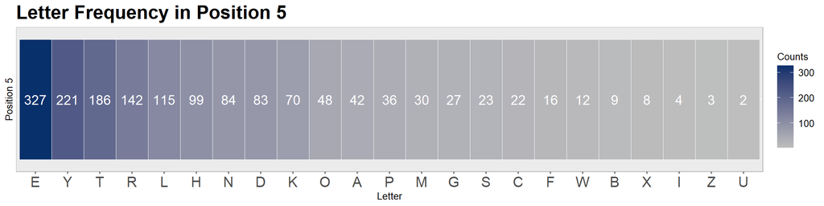

```r
# filtering for just position 5
position5_letter_freq <- positional_letter_frequency %>%
  filter(Position == "P5")

# heatmap figure
position5_letter_freq %>%
  ggplot(aes(x = reorder(Letter, -Counts), y = "P5", fill = Counts)) +
  geom_tile(color = "white") +
  geom_text(aes(label = Counts), color = "white", size = 5) +
  labs(
    title = "Letter Frequency in Position 5",
    x = "Letter",
    y = "Position 5"
  ) +
  scale_fill_gradient(
    low = "grey",
    high = "#08306b"   # dark
  ) +
  theme_calc() +
  theme(
  axis.text.y = element_blank(),
  axis.ticks.y = element_blank(),
  plot.title = element_text(size = 20, face = "bold"),
  axis.text.x = element_text(size = 15)
  )
```

To compare the possible endings directly, the following heatmap shows the frequencies for D, R, and S in Position 5:

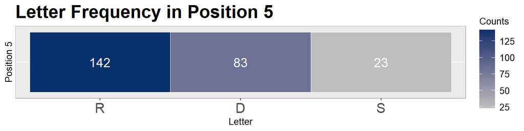

```r
# subset with only D R S
position5_subset <- position5_letter_freq %>%
  filter(Letter %in% c("D", "R", "S"))


# same plot as before just changed the data filtered in
position5_subset %>%
  ggplot(aes(x = reorder(Letter, -Counts), y = "P5", fill = Counts)) +
  geom_tile(color = "white") +
  geom_text(aes(label = Counts), color = "white", size = 5) +
  labs(
    title = "Letter Frequency in Position 5",
    x = "Letter",
    y = "Position 5"
  ) +
  scale_fill_gradient(
    low = "grey",
    high = "#08306b"   # dark
  ) +
  theme_calc() +
  theme(
  axis.text.y = element_blank(),
  axis.ticks.y = element_blank(),
  plot.title = element_text(size = 20, face = "bold"),
  axis.text.x = element_text(size = 15)
  )
```

The mini heatmap makes the comparison clearer. Among the three possible endings, R appears with the highest frequency in Position 5, D appears moderately often, and S is much less common. Based on these positional trends, BAKER is statistically the most likely answer for the pattern BAKE_.

### **Question 3 – Which letter pairs (bigrams) appear most often in Wordle solutions?**

English words often rely on recurring two-letter sequences, and these patterns appear throughout Wordle solutions as well. A bigram is a pair of consecutive letters. Each Wordle answer contains four bigrams that correspond to the following positions: letters (1,2), (2,3), (3,4), and (4,5). By counting how often each bigram appears across all solutions, we can identify the pairs that Wordle uses the most frequently.

The table below lists the ten most common bigrams in the dataset. Many of these pairs reflect familiar English patterns, including common prefixes, vowel to consonant transitions, and typical word endings.

```r
# pulling bigrams
bigrams <- wordle_data %>%
  mutate (B1 = paste0(P1, P2),  # paste0 no separator by default
          B2 = paste0(P2, P3),
          B3 = paste0(P3, P4),
          B4 = paste0(P4, P5)) %>%
  select(B1, B2, B3, B4) %>%
  pivot_longer(cols = everything(), names_to = "Position", values_to = "Bigram") %>% # names_to = col name to create from specified cols before, values_to = new column to create from values in each cell.
  group_by(Bigram) %>%
  summarise(Counts = n()) %>%
  arrange(-Counts)


bigrams %>%
  head(10) %>%
  kbl() %>%
  kable_styling() %>%
  scroll_box(width = "50%", height = "250px")
```

| Bigram | Counts |
| --- | --- |
| ER | 134 |
| IN | 94 |
| ST | 91 |
| RA | 80 |
| AR | 79 |
| RO | 78 |
| AL | 75 |
| CH | 75 |
| RE | 75 |
| EA | 73 |

The table highlights the ten most frequent bigrams, but a broader view helps reveal the full pattern. The following bar chart expands the ranking to the top twenty-five bigrams, making the distribution easier to compare. In this larger set, ER stands out as the most common bigram with 134 occurrences. It is followed by IN, ST, RA, and AR, all of which occur frequently in English and appear naturally throughout the Wordle list. These bigrams often represent common endings, prefixes, or internal transitions, which explains why players frequently encounter them in solutions. Seeing the wider distribution helps illustrate how strongly Wordle leans on familiar English letter sequences.

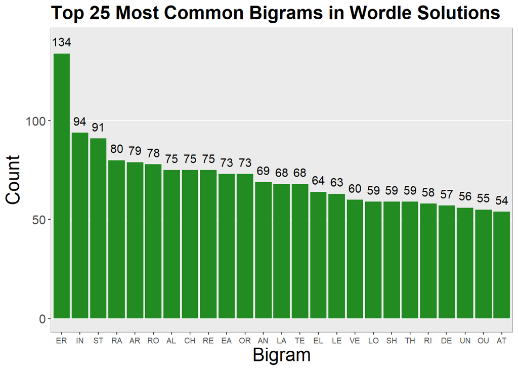

```r
# take top 25 bigrams and plot them
bigrams %>%  head(25) %>%
  ggplot(aes(x = reorder(Bigram, -Counts), y = Counts)) +
  geom_col(fill = "forestgreen") +
  geom_text(aes(label = Counts), nudge_y = 6, size = 4) +
  labs(
    title = "Top 25 Most Common Bigrams in Wordle Solutions",
    x = "Bigram",
    y = "Count"
  ) +
  theme_calc() +
  theme(
    plot.title = element_text(size = 18, face = "bold"),   # title size
    axis.title.x = element_text(size = 18),                # X label
    axis.title.y = element_text(size = 18),                # Y label
    axis.text.x = element_text(size = 8),                  # axis value labels
    axis.text.y = element_text(size = 12)
  )
```

The bar chart confirms the strong presence of these high-frequency patterns across the full Wordle answer list. Because bigrams like ER, IN, and ST occur so often, guesses containing these sequences tend to be more informative. Even when the entire guess is wrong, matching a common bigram can reveal valuable clues about the structure of the hidden word. This reinforces the idea that Wordle solutions are shaped by familiar English letter patterns rather than random combinations. After understanding which bigrams are most frequent overall, the next step is to see whether their behavior changes depending on where they appear within the word.

### **Question 4 - How does the bigram frequency change depending on where they appear in the word?**

While Question 3 examined bigrams across all positions, this section focuses on where those bigrams appear within Wordle solutions. Each answer contains four bigrams that correspond to the pairs of letters at positions (1,2), (2,3), (3,4), and (4,5). These are labeled B1 through B4. Because English words often follow predictable structures, the frequency of a bigram can change significantly depending on whether it appears at the beginning, middle, or end of a word. By breaking the counts down by position, we can see how Wordle mirrors these natural language patterns.

The following are the 4 possible bigram positions in a Wordle solution:

- B1: letters 1–2 (start of word)
- B2: letters 2–3
- B3: letters 3–4
- B4: letters 4–5 (end of word)

Each bigram position carries its own linguistic role. B1 often reflects common word openings. B2 and B3 tend to show transitional patterns that move between consonants and vowels. B4 usually represents endings or suffix-like patterns. The goal of this section is to show how the distribution shifts across these four positions.

```r
bigrams_by_position <- wordle_data %>%
  mutate (B1 = paste0(P1, P2),  # paste0 no separator by default
          B2 = paste0(P2, P3),
          B3 = paste0(P3, P4),
          B4 = paste0(P4, P5)) %>%
  select(B1, B2, B3, B4) %>%
  pivot_longer(cols = everything(), names_to = "Position", values_to = "Bigram") %>%
  group_by(Position, Bigram) %>%
  summarise(Counts = n()) %>%
  arrange(Position, -Counts)

bigrams_by_position %>%
  group_by(Position) %>%
  slice_max(Counts, n = 3) %>%
  kbl() %>%
  kable_styling() %>%
  scroll_box(width = "50%", height = "400px")
```

| Position | Bigram | Counts |
| --- | --- | --- |
| B1 | ST | 52 |
| B1 | SH | 34 |
| B1 | SP | 33 |
| B2 | RO | 51 |
| B2 | RA | 49 |
| B2 | RI | 43 |
| B3 | AR | 38 |
| B3 | IN | 37 |
| B3 | AS | 31 |
| B3 | EA | 31 |
| B4 | ER | 95 |
| B4 | CH | 39 |
| B4 | SE | 38 |

The table shows the three most frequent bigrams for each of the four positions, and it illustrates how different the distribution becomes once location is taken into account. In Position B1, the most common starting bigram is ST with 52 occurrences, followed by SH with 34 and SP with 33. These results match familiar English patterns where many words begin with strong consonant clusters. This indicates that Wordle solutions frequently start with structures that resemble standard English prefixes.

In Position B2, the most frequent bigrams shift to vowel–consonant or consonant–vowel transitions. RO appears 51 times, RA appears 49 times, and RI appears 43 times. These combinations help form smooth internal transitions within the word. The values show that B2 is less about fixed patterns and more about natural flow inside the word.

Position B3 shows another transition heavy region. AR appears 38 times, IN appears 37 times, and AS and EA follow with 31 occurrences each. This reflects the flexibility of the middle portion of English words. There is no single dominant bigram here. Instead, the data highlights how the middle of a word supports a broader variety of patterns.

Finally, Position B4 reveals the strongest structural pattern. ER appears 95 times, far more than any bigram in the other positions. CH appears 39 times, and SE appears 38 times. These are all common English endings that resemble suffix like behavior. The strength of ER in particular shows that Wordle endings follow predictable language patterns.

Across these results, it becomes clear that bigram frequency is highly dependent on position. Wordle solutions tend to start with consonant clusters, transition through varied internal combinations, and end with well known English endings. Position specific patterns of this type help explain why some guesses immediately eliminate many possibilities when the player knows the exact location of one or more letters.

After identifying the most frequent bigrams in each position through the summary table, the next step is to visualize these differences more clearly. The bar charts below display the top ten bigrams for each position. Plotting them side by side helps reveal how strongly each position leans toward certain structural patterns and makes it easier to compare the behavior of starting, middle, and ending bigrams.

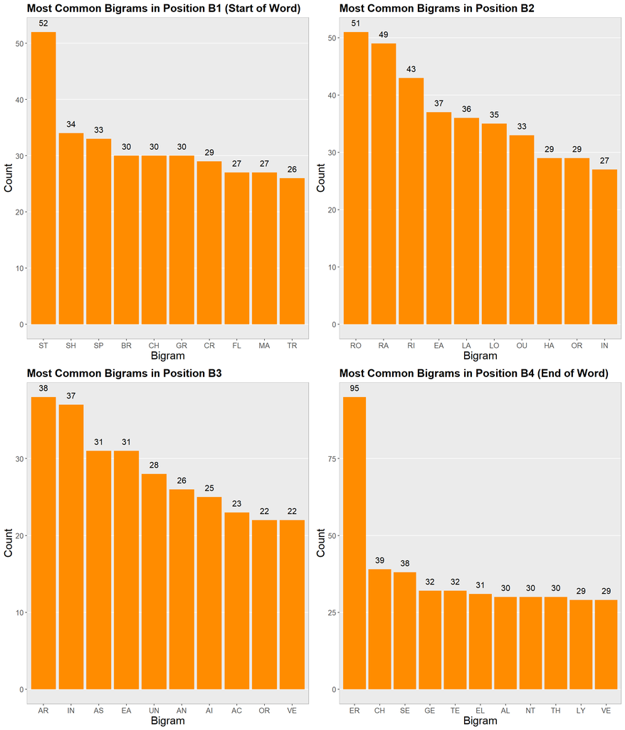

```r
top_bigrams_by_pos <- bigrams_by_position %>%
  group_by(Position) %>%
  slice_max(Counts, n = 10)


# plot for bigram 1
B1_plot <- top_bigrams_by_pos %>%
  filter(Position == "B1") %>%
  ggplot(aes(x = reorder(Bigram, -Counts), y = Counts)) +
  geom_col(fill = "darkorange") +
  geom_text(aes(label = Counts), vjust = -1, size = 4) +
  labs(
    title = "Most Common Bigrams in Position B1 (Start of Word)",
    x = "Bigram",
    y = "Count"
  ) +
  theme_calc() +
  theme(
    plot.title = element_text(size = 15, face = "bold"),   # title size
    axis.title.x = element_text(size = 15),                # X label
    axis.title.y = element_text(size = 15),                # Y label
    axis.text.x = element_text(size = 10),
    axis.text.y = element_text(size = 10)
    )


# plot for bigram 2
B2_plot <- top_bigrams_by_pos %>%
  filter(Position == "B2") %>%
  ggplot(aes(x = reorder(Bigram, -Counts), y = Counts)) +
  geom_col(fill = "darkorange") +
  geom_text(aes(label = Counts), vjust = -1, size = 4) +
  labs(
    title = "Most Common Bigrams in Position B2",
    x = "Bigram",
    y = "Count"
  ) +
  theme_calc() +
  theme(
    plot.title = element_text(size = 15, face = "bold"),   # title size
    axis.title.x = element_text(size = 15),                # X label
    axis.title.y = element_text(size = 15),                # Y label
    axis.text.x = element_text(size = 10),
    axis.text.y = element_text(size = 10)
    )

# plot for bigram 3
B3_plot <- top_bigrams_by_pos %>%
  filter(Position == "B3") %>%
  ggplot(aes(x = reorder(Bigram, -Counts), y = Counts)) +
  geom_col(fill = "darkorange") +
  geom_text(aes(label = Counts), vjust = -1, size = 4) +
  labs(
    title = "Most Common Bigrams in Position B3",
    x = "Bigram",
    y = "Count"
  ) +
  theme_calc() +
  theme(
    plot.title = element_text(size = 15, face = "bold"),   # title size
    axis.title.x = element_text(size = 15),                # X label
    axis.title.y = element_text(size = 15),                # Y label
    axis.text.x = element_text(size = 10),
    axis.text.y = element_text(size = 10)
    )

# plot for bigram 4
B4_plot <- top_bigrams_by_pos %>%
  filter(Position == "B4") %>%
  ggplot(aes(x = reorder(Bigram, -Counts), y = Counts)) +
  geom_col(fill = "darkorange") +
  geom_text(aes(label = Counts), vjust = -1, size = 4) +
  labs(
    title = "Most Common Bigrams in Position B4 (End of Word)",
    x = "Bigram",
    y = "Count"
  ) +
  theme_calc() +
  theme(
    plot.title = element_text(size = 15, face = "bold"),   # title size
    axis.title.x = element_text(size = 15),                # X label
    axis.title.y = element_text(size = 15),                # Y label
    axis.text.x = element_text(size = 10),
    axis.text.y = element_text(size = 10)
    )

grid.arrange(
  B1_plot, B2_plot,
  B3_plot, B4_plot,
  ncol = 2
)
```

The B4 chart, however, stands out the most. ER dominates the ending position with a count far higher than any other ending bigram. CH and SE follow behind it, both representing common English suffix patterns. The strong skew in the B4 distribution highlights how predictable English endings are compared to the internal structure of the word.

Overall, breaking down bigrams by position shows that Wordle words follow clear English structural tendencies. Words often begin with recognizable consonant clusters, transition through varied middle combinations, and end with predictable suffix patterns. Understanding these positional differences makes bigrams more useful during gameplay, because certain patterns are far more likely depending on where the letters appear. This helps guide strategic guesses and supports the idea that Wordle’s solution set mirrors natural English word formation.

### **So *how* can we apply this?**

Understanding positional bigram patterns becomes especially useful when solving a partially completed Wordle. Suppose the puzzle reveals the pattern BAK__, with only the last two letters missing. Several completions are possible:

- BAKER
- BAKED
- BAKES

Rather than guessing blindly, we can use the positional bigram data to identify which ending is most likely to appear among Wordle solutions. Because the final two letters form the bigram in position B4, we look specifically at how often ER, ED, and ES occur in that final slot.

```r
# pull end of word bigrams (B4)
# and display table
bigrams_by_position %>%
  filter(Position == "B4", Bigram %in% c("ER", "ED", "ES")) %>%
  kbl() %>%
  kable_styling() %>%
  scroll_box(width = "50%")
```

| Position | Bigram | Counts |
| --- | --- | --- |
| B4 | ER | 95 |
| B4 | ED | 7 |

From the data frequencies in B4 are as follows:

- ER occurs 95 times
- ED occurs 7 times
- ES occurs 0 times

ER stands out overwhelmingly as the most common ending among all Wordle solutions. This matches known English patterns since -ER is a frequent suffix found in many words.

Because ER is so dominant in the B4 position, the most probable answer for the pattern **BAK__** is **BAKER**.

This example shows how positional bigram frequency can move us beyond intuition, helping narrow down solutions by grounding each guess in real structural patterns found in the Wordle dataset.

### **FUN FACT AGAIN!**

The positional bigram data also reinforces the earlier observation about how rarely Wordle uses plural forms. In English, the suffix ES is a common way to pluralize words, but in the final bigram position (B4) it appears 0 times across the entire Wordle dataset. This matches the pattern seen in the positional heatmap from before where almost no solutions end with the letter S.

Taken together, the bigram table and the letter positional analysis show that typical plural endings such as ES are almost never selected as Wordle answers. Instead of forming five-letter solutions by attaching an S to a shorter base word, Wordle tends to choose words where every letter is part of the original root. This provides further evidence that plural formations are intentionally avoided in the answer list.

### **Question 5 - Do repeated letter Wordle answers follow seasonal or monthly patterns across different years?**

Repeated letters are common in English words, but it is not clear whether Wordle distributes these types of answers in any predictable way. Since the game is published every day, it is reasonable to wonder whether repeated-letter words cluster in certain months, appear more often during particular seasons, or follow some kind of scheduling rule. To investigate this, I examined how many repeated-letter solutions occurred in each month across multiple years.

The first step was to find the total number of repeated-letter answers per month. The table below summarizes these counts for every year in the dataset and gives a numerical overview of how often repeated-letter solutions appear.

```r
# pulling number of words with repeated letters
monthly_repeats <- wordle_data %>%
group_by(Year, Month) %>%               # we group by month AND year
summarise(
repeats = sum(Has.repeated.letters == 1))


monthly_repeats %>%
  kbl() %>%
  kable_styling() %>%
  scroll_box(width = "50%", height = "300px")
```

| Year | Month | repeats |
| --- | --- | --- |
| 2021 | June | 7 |
| 2021 | July | 11 |
| 2021 | August | 14 |
| 2021 | September | 12 |
| 2021 | October | 13 |
| 2021 | November | 6 |
| 2021 | December | 4 |
| 2022 | January | 8 |
| 2022 | February | 9 |
| 2022 | March | 9 |
| 2022 | April | 5 |
| 2022 | May | 7 |
| 2022 | June | 9 |
| 2022 | July | 14 |
| 2022 | August | 8 |
| 2022 | September | 12 |
| 2022 | October | 9 |
| 2022 | November | 6 |
| 2022 | December | 8 |
| 2023 | January | 9 |
| 2023 | February | 12 |
| 2023 | March | 7 |
| 2023 | April | 8 |
| 2023 | May | 7 |
| 2023 | June | 10 |
| 2023 | July | 7 |
| 2023 | August | 10 |
| 2023 | September | 8 |
| 2023 | October | 6 |
| 2023 | November | 10 |
| 2023 | December | 8 |
| 2024 | January | 6 |
| 2024 | February | 10 |
| 2024 | March | 7 |
| 2024 | April | 6 |
| 2024 | May | 9 |
| 2024 | June | 10 |
| 2024 | July | 9 |
| 2024 | August | 5 |
| 2024 | September | 9 |
| 2024 | October | 10 |
| 2024 | November | 13 |
| 2024 | December | 6 |
| 2025 | January | 13 |
| 2025 | February | 12 |
| 2025 | March | 10 |
| 2025 | April | 11 |
| 2025 | May | 11 |
| 2025 | June | 10 |
| 2025 | July | 10 |
| 2025 | August | 11 |
| 2025 | September | 7 |
| 2025 | October | 12 |
| 2025 | November | 4 |

The monthly values show a wide range of variation. For example, in 2021 the counts range from 4 in December to 14 in August. In 2022 the highest month is July with 14 repeated-letter answers, while April contains only 5. The variation continues in later years. Some months have noticeably high counts in certain years and noticeably low counts in others. These changes do not follow a consistent pattern.

To visualize the trends more clearly, I created a line plot that displays monthly repeated-letter counts separated by year.

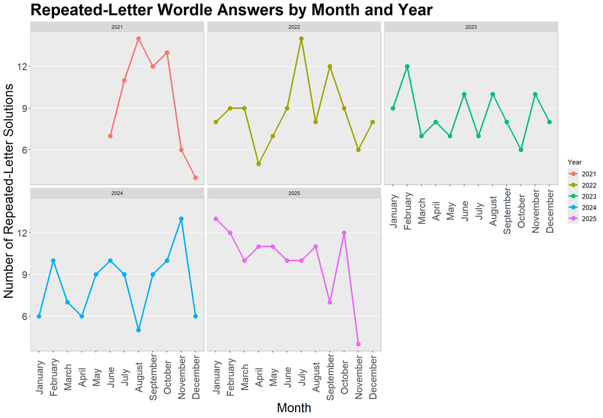

```r
# line graph by year
monthly_repeats %>%
  ggplot(aes(x = Month, y = repeats, group = Year, color = factor(Year))) +
  geom_line(size = 1.2) +
  geom_point(size = 3) +
  facet_wrap(~Year) +
  labs(
  title = "Repeated-Letter Wordle Answers by Month and Year",
  x = "Month",
  y = "Number of Repeated-Letter Solutions",
  color = "Year"
  ) +
  theme_calc() +
  theme(
    plot.title = element_text(size = 25, face = "bold"),   # title size
    axis.title.x = element_text(size = 20),                # X label
    axis.title.y = element_text(size = 20),                # Y label
    axis.text.x = element_text(angle = 90, vjust = 0.5, size = 15),
    axis.text.y = element_text(size = 15)
    )
```

The line plots confirm that the number of repeated-letter answers changes from month to month, but not in a consistent or predictable way. Some years show spikes in certain months, while others show dips in those same months. If a seasonal pattern existed, the lines for each year would show similar shapes or similar rises and falls. Instead, each year displays its own unrelated pattern.

To explore the distribution in more detail, I created monthly calendar heatmaps. Each calendar highlights the exact days that contain repeated-letter solutions. The example below shows January across several years. Light blue squares mark days with repeated letters.

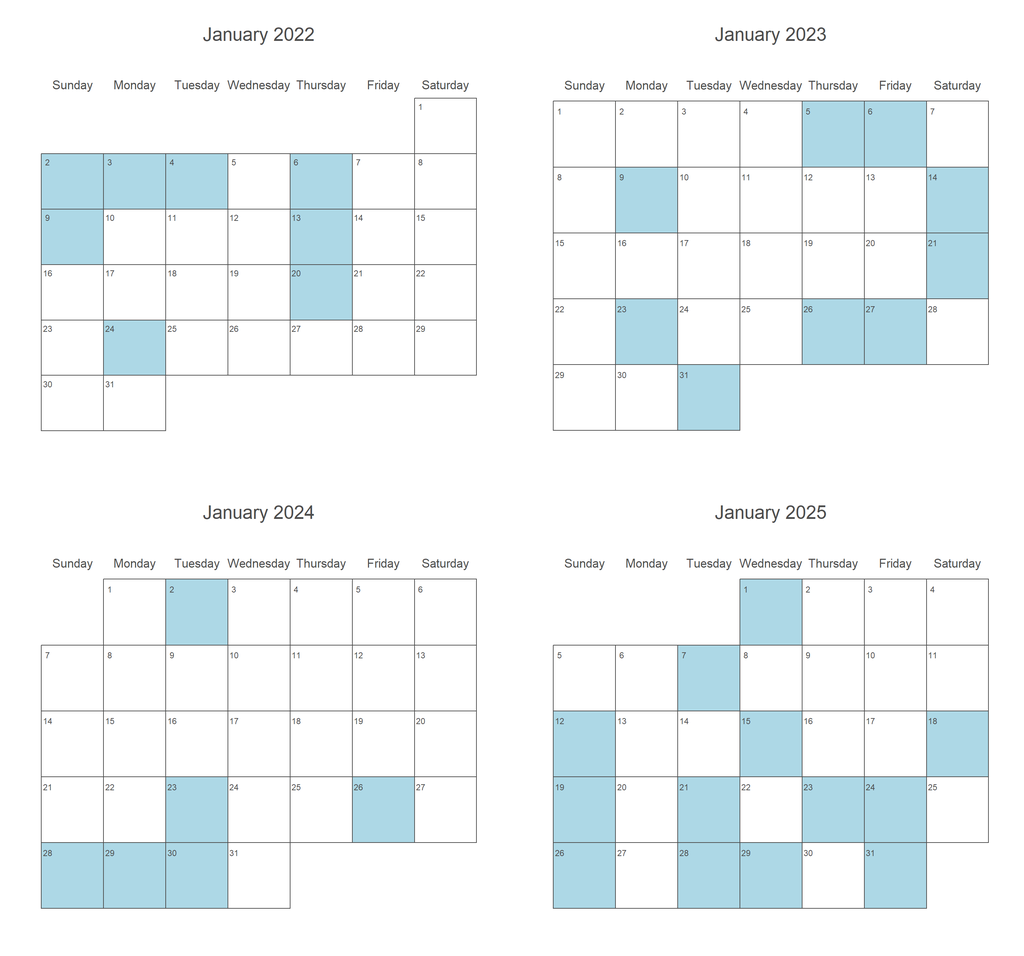

```r
# adding a numeric month column so I can match months correctly
wordle_data <- wordle_data %>%
  mutate(
    Month.num = match(Month, month.name)
  )

# function to create one calendar for a given year and month
make_calendar <- function(y, m) {

  # pulls only the exact days in that month that have repeated-letter answers
  repeated_days <- wordle_data %>%
    filter(Year == y, Month.num == m, `Has.repeated.letters` == 1) %>%
    pull(Day)

  # actual calendar plot
  calendR(
    year = y,
    month = m,
    start = "S",        # week start on sunday
    title = paste(month.name[m], y),
    special.days = repeated_days,    # indicates days to color (this is why I pulled the days above)
    special.col = "lightblue"       # color for the special days ^
  )
}

# hardcoding cases :(
# not all years have the same amount of data
# 2021 data started aug
# 2025 data is from jan - nov
year_plots <- function(month, yearStart, yearEnd){

  if (yearStart == 2022 && yearEnd == 2025) {

    y22 <- make_calendar(2022, month)
    y23 <- make_calendar(2023, month)
    y24 <- make_calendar(2024, month)
    y25 <- make_calendar(2025, month)

    grid.arrange(
      y22, y23,
      y24, y25,
      ncol = 2
    )

  } else if (yearStart == 2021 && yearEnd == 2024) {

    y21 <- make_calendar(2021, month)
    y22 <- make_calendar(2022, month)
    y23 <- make_calendar(2023, month)
    y24 <- make_calendar(2024, month)

    grid.arrange(
      y21, y22,
      y23, y24,
      ncol = 2
    )

  } else if (yearStart == 2021 && yearEnd == 2025) {

    y21 <- make_calendar(2021, month)
    y22 <- make_calendar(2022, month)
    y23 <- make_calendar(2023, month)
    y24 <- make_calendar(2024, month)
    y25 <- make_calendar(2025, month)

    grid.arrange(
      y21, y22,
      y23, y24,
      y25,
      ncol = 2
    )

  }
}

# jan plot
year_plots(01, 2022, 2025)
```

```r
# testing other plots here

#year_plots(02, 2022, 2025)
#year_plots(03, 2022, 2025)
#year_plots(04, 2022, 2025)
#year_plots(05, 2022, 2025)
#year_plots(06, 2021, 2025)
#year_plots(07, 2021, 2025)
#year_plots(08, 2021, 2025)
#year_plots(09, 2021, 2025)
#year_plots(10, 2021, 2025)
#year_plots(11, 2021, 2025)
#year_plots(12, 2021, 2024)
```

The heatmaps show that the placement of repeated-letter answers shifts around without any stable pattern. Some years have several repeated letters near the beginning of the month, some near the end, and others are evenly scattered. There is no monthly rhythm or seasonal cycle that repeats across years.

Taken together, the table, line plots, and heatmaps all point to the same conclusion. The distribution of repeated-letter Wordle solutions does not follow a consistent pattern across months or seasons. The placement appears random rather than structured. This suggests that the puzzle generator does not intentionally space out or cluster repeated-letter answers, and that these words occur independently of time-based factors.

The analysis of repeated-letter patterns showed that Wordle does not seem to follow any kind of seasonal or monthly structure when selecting solutions. Once that question was resolved, I wanted to shift to a different type of linguistic pattern that is not tied to time at all. Instead of looking at when certain words appear, the next question looks at how words behave in the English language more broadly. Specifically, I wondered whether a word’s frequency in everyday English is related to how valuable that same word would be in Scrabble.

This moves the focus from temporal patterns to linguistic characteristics. While Wordle’s word list is not designed for Scrabble, both games rely on the structure of English vocabulary. It is reasonable to ask whether common words tend to have lower Scrabble point values, or whether rare words tend to score higher because they contain less frequent letters.

This leads to the next question.

### **Question 6 - Is there a relationship between a word’s frequency in English and its Scrabble point value?**

Wordle words vary in both their frequency in the English language and their Scrabble score. It seems reasonable to wonder whether these two properties are related. Rare words often contain unusual letters such as X, Z, Q, or J, which carry high Scrabble values, while common words usually rely on frequent letters such as E, A, N, or R, which have low Scrabble scores. If this pattern held strongly in Wordle, then rare words would tend to score high and common words would tend to score low.

To explore this idea, I grouped all Wordle solutions into frequency categories and compared their Scrabble scores. This allows us to see whether certain categories consistently score higher or lower than others.

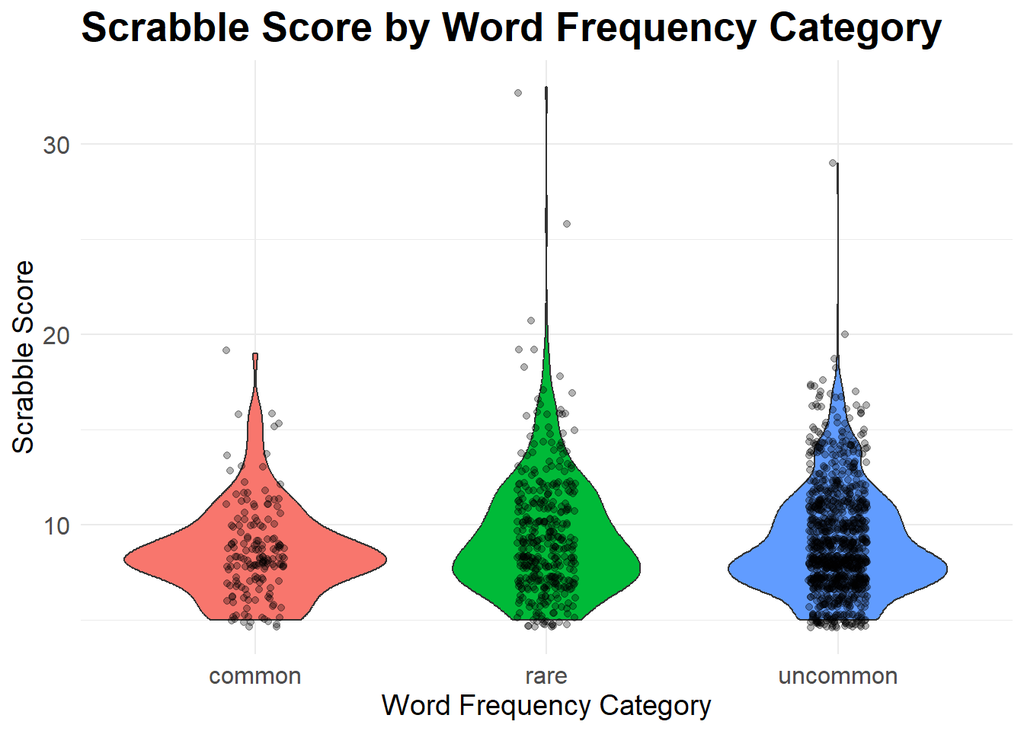

```r
ggplot(wordle_data, aes(x = Frequency.category, y = Scrabble.score, fill = Frequency.category)) +
  geom_violin() +
  geom_jitter(width = 0.1, alpha = 0.3, color = "black", size = 1.5) +
  labs(
    title = "Scrabble Score by Word Frequency Category",
    x = "Word Frequency Category",
    y = "Scrabble Score"
  ) +
  theme_minimal() +
  theme(
    plot.title = element_text(size = 20, face = "bold"),
    axis.title = element_text(size = 14),
    axis.text = element_text(size = 12),
    legend.position = "none"
  )
```

The violin plot shows the spread of Scrabble scores across rare, uncommon, and common words. The distributions overlap heavily, and none of the categories displays a clearly higher or lower scoring pattern. This suggests that Wordle does not favor high-value letters in rare words or low-value letters in common words. Instead, the Scrabble scores appear largely independent of how frequent a word is in general English text.

Although Scrabble scores do not show a strong relationship with frequency, the distribution of words across frequency categories reveals a clear pattern. The “Uncommon” category is much denser than both the “Common” and “Rare” categories. The violin plot shows many more Wordle answers falling in the middle frequency range, while very common words and extremely rare words appear far less often. This suggests that Wordle intentionally favors words that are familiar enough to recognize but not used constantly in everyday language. These words provide challenge without feeling unfair or obscure.

### **Fun Data**

The following tables provide a closer look at specific extremes in the dataset. These examples help illustrate how word frequency and Scrabble scores behave independently.

**Wordle with the lowest corpus frequency**

```r
wordle_data %>%
  filter(Word.Frequency == min(Word.Frequency)) %>%
  select(Answer, Word.Frequency, Frequency.category) %>%
  kbl() %>%
  kable_styling() %>%
  scroll_box(width = "50%")
```

| Answer | Word.Frequency | Frequency.category |
| --- | --- | --- |
| WOOER | 0 | rare |

**Wordle with the highest corpus frequency**

```r
wordle_data %>%
  filter(Word.Frequency == max(Word.Frequency)) %>%
  select(Answer, Word.Frequency, Frequency.category) %>%
  kbl() %>%
  kable_styling() %>%
  scroll_box(width = "60%")
```

| Answer | Word.Frequency | Frequency.category |
| --- | --- | --- |
| ABOUT | 0.00251 | common |

**Three lowest Scrabble score Wordles per frequency category**

```r
wordle_data %>%
  group_by(Frequency.category) %>%
  slice_min(Scrabble.score, n = 3, with_ties = FALSE) %>%
  select(Answer, Scrabble.score, Frequency.category) %>%
  kbl() %>%
  kable_styling() %>%
  scroll_box(width = "60%", height = "60%")
```

| Answer | Scrabble.score | Frequency.category |
| --- | --- | --- |
| LATER | 5 | common |
| LEAST | 5 | common |
| UNION | 5 | common |
| ELATE | 5 | rare |
| LORIS | 5 | rare |
| STILT | 5 | rare |
| ARISE | 5 | uncommon |
| STUNT | 5 | uncommon |
| TENOR | 5 | uncommon |

**Three highest Scrabble score Wordles per frequency category**

```r
wordle_data %>%
  group_by(Frequency.category) %>%
  slice_max(Scrabble.score, n = 3, with_ties = FALSE) %>%
  select(Answer, Scrabble.score, Frequency.category) %>%
  kbl() %>%
  kable_styling() %>%
  scroll_box(width = "60%", height = "60%")
```

| Answer | Scrabble.score | Frequency.category |
| --- | --- | --- |
| CRAZY | 19 | common |
| CHECK | 16 | common |
| WHICH | 16 | common |
| JAZZY | 33 | rare |
| TIZZY | 26 | rare |
| JIFFY | 21 | rare |
| FUZZY | 29 | uncommon |
| QUICK | 20 | uncommon |
| JERKY | 19 | uncommon |

Together, these summaries reinforce the main result. Common words, rare words, and everything in between can all have low or high Scrabble scores. Letters that drive Scrabble value do not map cleanly onto how often a word appears in English. Wordle’s solution list includes a mixture at all levels, with no clear relationship between how frequently a word is used and how valuable it would be in Scrabble.

# **Summary**

This analysis of more than 1,600 Wordle solutions reveals both predictable patterns and surprising gaps in the game’s word choices. Many patterns reflect natural properties of English, while others highlight deliberate design decisions within Wordle’s answer list.

- Letter and positional patterns:
  - Words often begin with familiar consonant clusters such as ST, SH, and BR, while the endings frequently include suffix-like patterns such as ER, CH, and GE. Vowels tend to appear near the center of words, which matches typical English spelling structure.
- Bigrams reveal structure:
  - Common letter pairs like ER, IN, and ST dominate specific positions in the word. These patterns explain why certain guesses eliminate many possibilities quickly, especially when the correct letter pair sits in a position typical for English words.
- Rare plurals:
  - Very few Wordle solutions end in “S”, and the bigram “ES” does not appear in the final position at all. This supports the observation that Wordle avoids simple plural forms created by adding an S to a base word.
- Repeated letters:
  - Words containing repeated letters appear in different months and years without any consistent pattern. Calendar visualizations and line plots show that their placement does not follow a seasonal cycle or a predictable monthly trend.
- Scrabble scores vs. frequency:
  - Scrabble points are influenced by the presence of rare letters like Q, Z, and X, while common letters tend to keep scores low. However, word frequency does not strongly predict a word’s Scrabble value.
  - The most notable trend is that the “Uncommon” frequency category contains far more Wordle answers than the “Common” or “Rare” categories, which suggests that Wordle prefers words that are familiar but not overly common.

Limitations:

One thing to keep in mind is that the word-frequency values in this project come from the wordfreq Python library. It provides reasonable estimates for how often words appear in general English based on its available corpora, but it is still just one model of frequency. After pulling those values, I created my own thresholds to label words as “Common,” “Uncommon,” or “Rare,” which means those categories work well for comparison but shouldn’t be treated as strict linguistic classifications.

Even with these limits, the larger trends such as common bigrams, vowel placement, the scarcity of plurals, and the randomness of repeated letters still show up clearly across the full dataset.

Overall, Wordle solutions may feel random, but they follow subtle English patterns. Understanding these tendencies, such as common letter positions, frequent bigrams, the avoidance of plural forms, and the behavior of repeated letters, can give players a more informed strategy. These insights help explain why some guesses are more effective than others and provide a structured approach for tackling future puzzles.

# **Final Fun Fact**

One Wordle answer that really stuck with me was KEFIR. I remember staring at it thinking, *how* is this even a Wordle word? It stuck with me so much that I ended up naming my Baldur’s Gate character after it. Her name is Kefir, all because of that one puzzle.

To see why KEFIR felt weird, I pulled some info about it:

```r
wordle_data %>%
  filter(Answer == "KEFIR") %>%
  select(Answer,Date, Word.Frequency, Frequency.category,Scrabble.score) %>%
  kbl() %>%
  kable_styling() %>%
  scroll_box(width = "100%")
```

| Answer | Date | Word.Frequency | Frequency.category | Scrabble.score |
| --- | --- | --- | --- | --- |
| KEFIR | 2025-08-13 | 1e-07 | rare | 12 |

So yeah, KEFIR really is rare. Also when the dataset is sorted from lowest to highest frequency, KEFIR shows up early in the rare list. So my confusion was justified. Wordle basically handed me a niche grocery store item and said “good luck”.